# Norwegian Hydro Power Generation — Forecasting Analysis

Carla de Erausquin (185899)

Christoph Schilling (185939)

Florencia Cecilia Brazionis (175974)

José Miguel Gomes Queirós Lobo (185920)

13 June 2026

# 1 Load and Prepare the Data

```r
raw <- read_delim("data/hydro-dataset.csv",
                  delim     = ";",
                  skip      = 1,
                  col_names = TRUE)

colnames(raw)[1:5]
```

```
## [1] "production and consumption" "Electricity power 1993M01"
## [3] "Electricity power 1993M02"  "Electricity power 1993M03"
## [5] "Electricity power 1993M04"
```

```r
nrow(raw)
```

```
## [1] 2
```

```r
long <- raw %>%
  rename_with(~ "series", .cols = 1) %>%
  filter(!is.na(series), series != "") %>%
  pivot_longer(
    cols      = -series,
    names_to  = "month_raw",
    values_to = "TWh"
  ) %>%
  mutate(
    month_code = str_extract(month_raw, "[0-9]{4}M[0-9]{2}"),
    year_part  = as.integer(substr(month_code, 1, 4)),
    mon_part   = as.integer(substr(month_code, 6, 7)),
    Month      = yearmonth(make_date(year_part, mon_part, 1)),
    TWh        = as.numeric(TWh)
  ) %>%
  filter(!is.na(Month), !is.na(TWh)) %>%
  select(series, Month, TWh)

print(long, n = 10)
```

```
## # A tibble: 798 × 3
##    series                             Month      TWh
##    <chr>                              <mth>    <dbl>
##  1 1 Total electricity generation  1993 Jan 11718176
##  2 1 Total electricity generation  1993 Feb 10675869
##  3 1 Total electricity generation  1993 Mar 11406111
##  4 1 Total electricity generation  1993 Apr  9464337
##  5 1 Total electricity generation  1993 May  8339679
##  6 1 Total electricity generation  1993 Jun  8160956
##  7 1 Total electricity generation  1993 Jul  7418503
##  8 1 Total electricity generation  1993 Aug  8122230
##  9 1 Total electricity generation 1993 Sept  9349530
## 10 1 Total electricity generation  1993 Oct 10718685
## # ℹ 788 more rows
```

```r
cat("\nUnique series:\n"); print(unique(long$series))
```

```
##
## Unique series:
```

```
## [1] "1 Total electricity generation" "1.1 Hydro power generation"
```

```r
cat("\nDate range:",
    as.character(min(long$Month)), "to",
    as.character(max(long$Month)), "\n")
```

```
##
## Date range: 1993 Jan to 2026 Mar
```

```r
total_elec <- long %>%
  filter(grepl("Total", series)) %>%
  select(Month, TWh) %>%
  mutate(TWh = TWh / 1e6) %>%
  as_tsibble(index = Month)

hydro <- long %>%
  filter(grepl("Hydro", series)) %>%
  select(Month, TWh) %>%
  mutate(TWh = TWh / 1e6) %>%
  as_tsibble(index = Month)

head(total_elec) %>% kable(align = "c", caption = "Total Electricity — first rows")
```

Total Electricity — first rows

| Month | TWh |
| --- | --- |
| 1993 Jan | 11.718176 |
| 1993 Feb | 10.675869 |
| 1993 Mar | 11.406111 |
| 1993 Apr | 9.464337 |
| 1993 May | 8.339679 |
| 1993 Jun | 8.160956 |

```r
head(hydro)       %>% kable(align = "c", caption = "Hydro — first rows")
```

Hydro — first rows

| Month | TWh |
| --- | --- |
| 1993 Jan | 11.673067 |
| 1993 Feb | 10.636402 |
| 1993 Mar | 11.377918 |
| 1993 Apr | 9.426997 |
| 1993 May | 8.292378 |
| 1993 Jun | 8.112115 |

```r
summary(hydro$TWh)
```

```
##    Min. 1st Qu.  Median    Mean 3rd Qu.    Max.
##   5.564   9.436  10.672  10.754  12.088  16.448
```

```r
range(hydro$TWh)
```

```
## [1]  5.563904 16.448465
```

```r
range(hydro$Month)
```

```
## <yearmonth[2]>
## [1] "1993 Jan" "2026 Mar"
```

```r
has_gaps(total_elec)
```

```
## # A tibble: 1 × 1
##   .gaps
##   <lgl>
## 1 FALSE
```

```r
scan_gaps(total_elec)
```

```
## # A tsibble: 0 x 1 [?]
## # ℹ 1 variable: Month <mth>
```

```r
has_gaps(hydro)
```

```
## # A tibble: 1 × 1
##   .gaps
##   <lgl>
## 1 FALSE
```

```r
scan_gaps(hydro)
```

```
## # A tsibble: 0 x 1 [?]
## # ℹ 1 variable: Month <mth>
```

# 2 Preliminary Visual Analysis

## 2.1 Time Plots

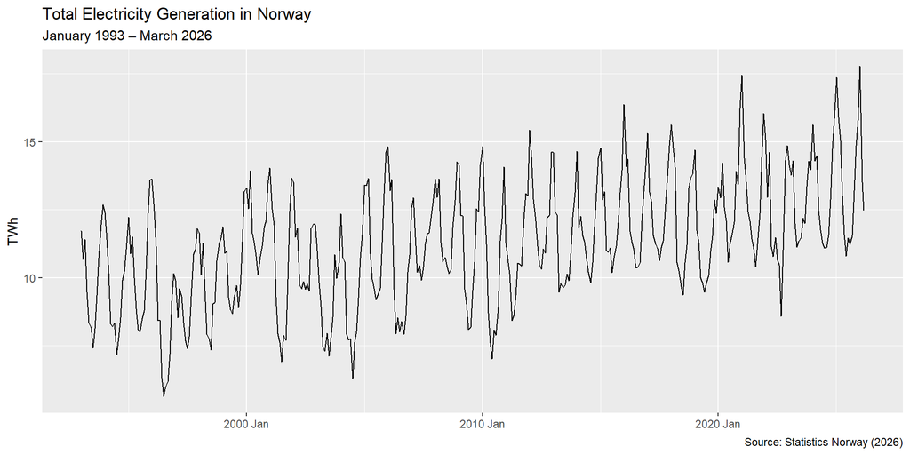

```r
total_elec %>%
  autoplot(TWh) +
  labs(title    = "Total Electricity Generation in Norway",
       subtitle = "January 1993 – March 2026",
       caption  = "Source: Statistics Norway (2026)",
       y = "TWh", x = NULL)
```

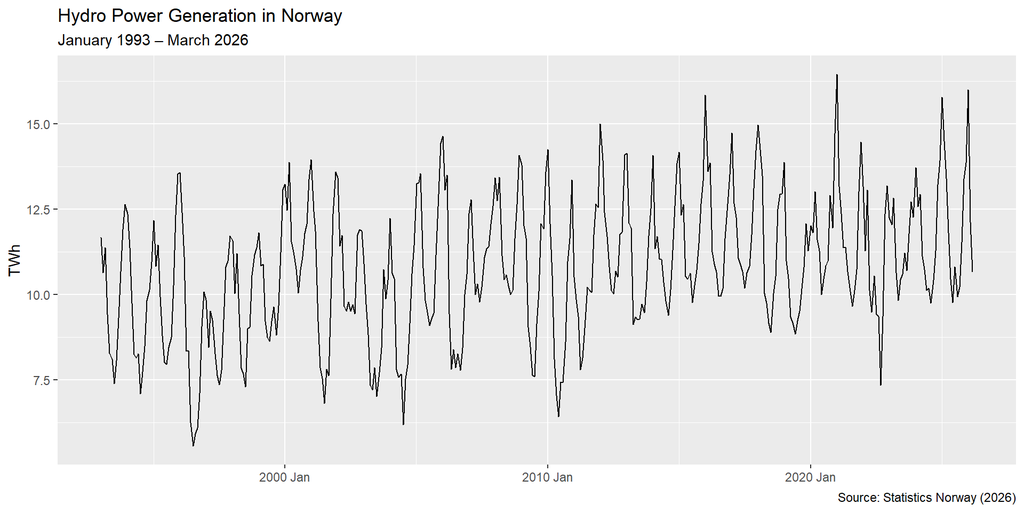

```r
hydro %>%
  autoplot(TWh) +
  labs(title    = "Hydro Power Generation in Norway",
       subtitle = "January 1993 – March 2026",
       caption  = "Source: Statistics Norway (2026)",
       y = "TWh", x = NULL)
```

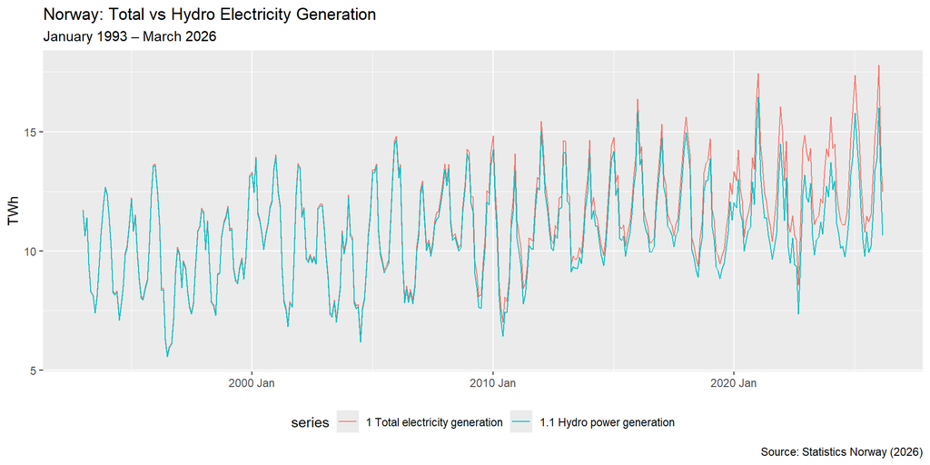

```r
long %>%
  mutate(Month = yearmonth(Month), TWh = TWh / 1e6) %>%
  as_tsibble(index = Month, key = series) %>%
  autoplot(TWh) +
  labs(title = "Norway: Total vs Hydro Electricity Generation",
       subtitle = "January 1993 – March 2026",
       caption  = "Source: Statistics Norway (2026)",
       y = "TWh", x = NULL) +
  theme(legend.position = "bottom")
```

## 2.2 Hydro as a Share of Total Generation

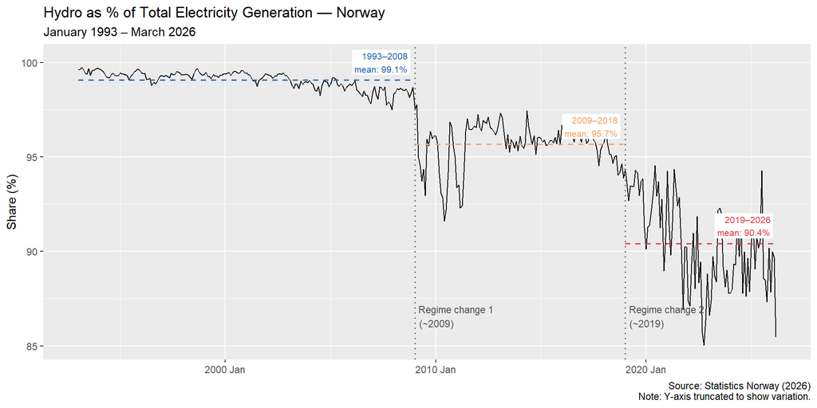

```r
# Join data
share <- inner_join(
  total_elec %>% rename(total = TWh),
  hydro       %>% rename(hydro  = TWh),
  by = "Month"
) %>%
  mutate(hydro_share = hydro / total * 100)

# Define break points
break1 <- yearmonth("2009 Jan")
break2 <- yearmonth("2019 Jan")

# Compute period means
period_means <- share %>%
  as_tibble() %>%
  mutate(period = case_when(
    Month < break1 ~ "1993–2008",
    Month < break2 ~ "2009–2018",
    TRUE           ~ "2019–2026"
  )) %>%
  group_by(period) %>%
  summarise(
    mean_share = mean(hydro_share),
    x_start    = min(Month),
    x_end      = max(Month),
    .groups = "drop"
  )

# Period mean colours
period_colours <- c(
  "1993–2008" = "#2166ac",
  "2009–2018" = "#f4a261",
  "2019–2026" = "#e63946"
)

# Plot
share %>%
  autoplot(hydro_share) +

  # --- Vertical structural break lines ---
  geom_vline(xintercept = as.Date(break1),
           linetype = "dotted", colour = "grey40", linewidth = 0.6) +
  geom_vline(xintercept = as.Date(break2),
           linetype = "dotted", colour = "grey40", linewidth = 0.6) +

  # --- Break labels ---
  annotate("text", x = as.Date(break1), y = 86,
         label = "Regime change 1\n (~2009)",
         hjust = -0.05, vjust = 0, size = 3, colour = "grey30") +
  annotate("text", x = as.Date(break2), y = 86,
         label = "Regime change 2\n (~2019)",
         hjust = -0.05, vjust = 0, size = 3, colour = "grey30") +

  # --- Period mean segments ---
  geom_segment(
    data = period_means,
    aes(x = x_start, xend = x_end,
        y = mean_share, yend = mean_share,
        colour = period),
    linetype = "dashed", linewidth = 0.7,
    inherit.aes = FALSE
  ) +

  # --- Period mean labels ---
  geom_label(
    data = period_means,
    aes(x = x_end, y = mean_share,
        label = paste0(period, "\nmean: ", round(mean_share, 1), "%"),
        colour = period),
    hjust = 1.05, vjust = -0.2, size = 2.8,
    label.size = NA, fill = "white", inherit.aes = FALSE
  ) +
  coord_cartesian(ylim = c(NA, 100.2)) +

  # --- Y-axis truncation note ---
  labs(
    title    = "Hydro as % of Total Electricity Generation — Norway",
    subtitle = "January 1993 – March 2026",
    y        = "Share (%)",
    x        = NULL,
    caption  = "Source: Statistics Norway (2026)\nNote: Y-axis truncated to show variation.",
    colour   = "Period"
  ) +

  scale_colour_manual(values = period_colours) +
  theme(legend.position = "none")
```

**Description:** Norway’s electricity grid has transitioned from near-total hydro dependence toward a more diversified mix of renewable energy sources (thermal, wind and solar). This shift is punctuated by two discrete structural breaks rather than a gradual decline.

The share of hydro power generation has declined from an average of 99.1% between 1993–2008 to an average of 90.4% in 2019–2026 – a near 9 percentage points drop.

## 2.3 Seasonal Plots

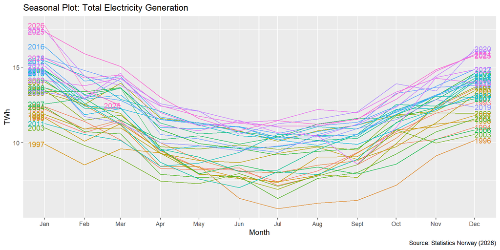

```r
total_elec %>%
  gg_season(TWh, labels = "both") +
  labs(
    title = "Seasonal Plot: Total Electricity Generation",
    y = "TWh",
    caption  = "Source: Statistics Norway (2026)"
  )
```

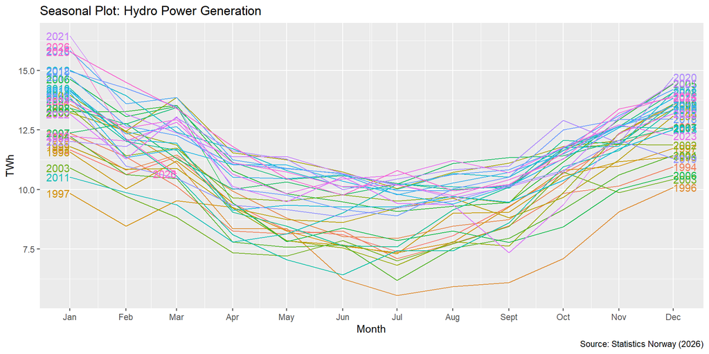

```r
hydro %>%
  gg_season(TWh, labels = "both") +
  labs(
    title = "Seasonal Plot: Hydro Power Generation",
    y = "TWh",
    caption  = "Source: Statistics Norway (2026)"
  )
```

**Description:** - Generation is highest in **December–February** and lowest in **June–August**. - The shape is consistent across years, confirming stable seasonality. - Some years (dry years) show notably lower summer generation.

## 2.4 Seasonal Subseries Plots

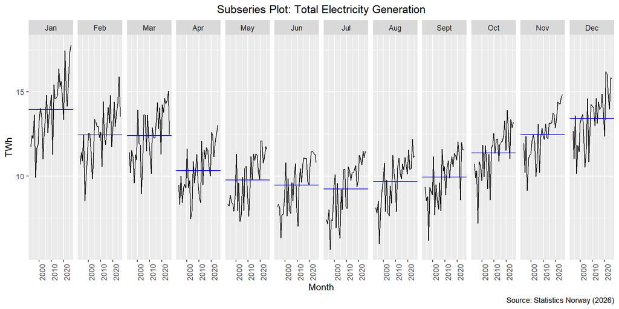

```r
total_elec %>%
  gg_subseries(TWh) +
  labs(
    title = "Subseries Plot: Total Electricity Generation",
    y = "TWh",
    caption  = "Source: Statistics Norway (2026)"
  ) +
  theme(plot.title = element_text(hjust = 0.5))
```

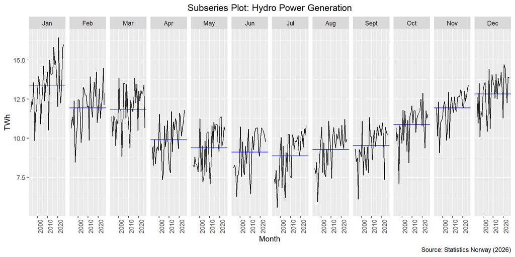

```r
hydro %>%
  gg_subseries(TWh) +
  labs(
    title = "Subseries Plot: Hydro Power Generation",
    y = "TWh",
    caption  = "Source: Statistics Norway (2026)"
  ) +
  theme(plot.title = element_text(hjust = 0.5))
```

**Description:** - Blue horizontal lines (monthly means) confirm the seasonal pattern: winter months (Jan–Mar, Nov–Dec) average 12–14 TWh, while summer months (Jun–Aug) average 9–10 TWh. - Within-month trends show a mild upward drift in recent years, most visible in January and December, suggesting generation capacity has grown over time rather than remaining flat. - Both series are nearly identical in shape and scale, reflecting hydro’s continued dominance — the main difference being slightly higher variance in Hydro, consistent with its exposure to precipitation and reservoir levels.

## 2.5 Lag Plots

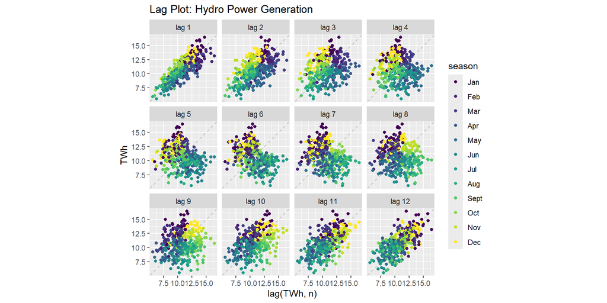

```r
hydro %>%
  gg_lag(TWh, geom = "point", lags = 1:12) +
  labs(title = "Lag Plot: Hydro Power Generation")
```

**Description:** - Strong positive autocorrelation at **lags 1–2**. - Strong positive correlation at **lag 12**, confirming annual seasonality. - **Lag 6** shows weaker correlation — the opposite season.

## 2.6 Annual Totals

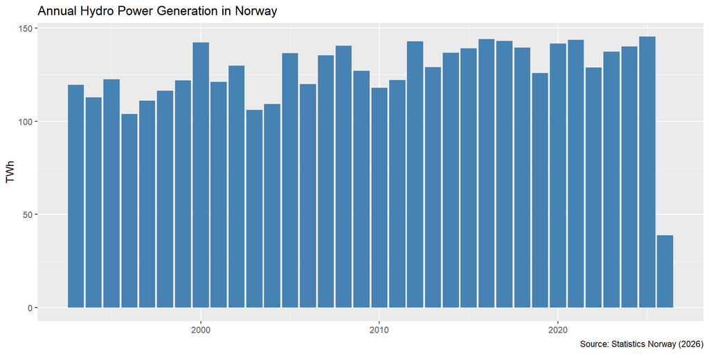

```r
hydro %>%
  mutate(Year = year(Month)) %>%
  as_tibble() %>%
  group_by(Year) %>%
  summarise(Annual_TWh = sum(TWh, na.rm = TRUE), .groups = "drop") %>%
  ggplot(aes(x = Year, y = Annual_TWh)) +
  geom_col(fill = "steelblue") +
  labs(
    title = "Annual Hydro Power Generation in Norway",
    y = "TWh",
    x = NULL,
    caption  = "Source: Statistics Norway (2026)"
  )
```

# 3 Transformation

## 3.1 Box-Cox Check

```r
lambda <- hydro %>%
  features(TWh, features = guerrero)
lambda
```

```
## # A tibble: 1 × 1
##   lambda_guerrero
##             <dbl>
## 1            1.46
```

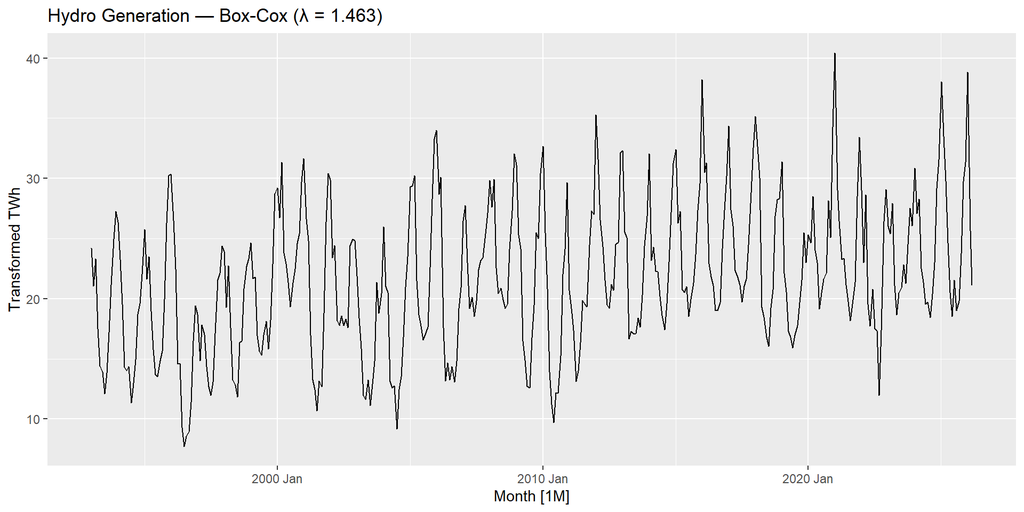

```r
hydro %>%
  autoplot(box_cox(TWh, lambda$lambda_guerrero)) +
  labs(title = paste0("Hydro Generation — Box-Cox (λ = ",
                      round(lambda$lambda_guerrero, 3), ")"),
       y = "Transformed TWh")
```

**Description:** λ ≈ 1.463 is close to 1, suggesting little transformation is strictly needed — the variance is already quite stable. However, we also consider a log transformation for interpretability.

## 3.2 Log Transformation

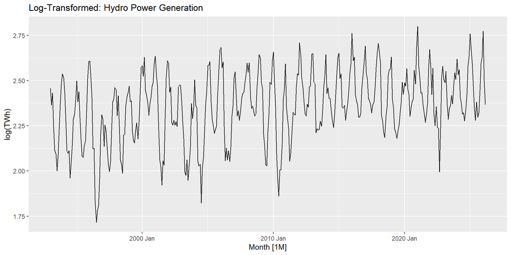

```r
hydro <- hydro %>%
  mutate(log_TWh = log(TWh))

hydro %>%
  autoplot(log_TWh) +
  labs(title = "Log-Transformed: Hydro Power Generation",
       y = "log(TWh)")
```

**Description:** The log scale stabilises the variance slightly and will be used for the STL decomposition and model estimation.

# 4 Decomposition

## 4.1 STL Decomposition — Levels

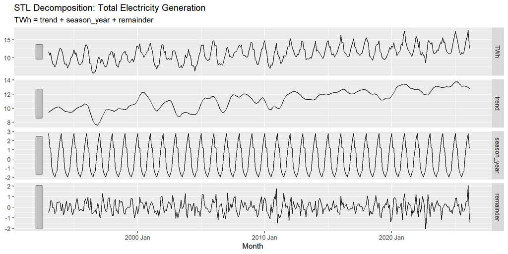

```r
total_elec %>%
  model(STL(TWh ~ trend(window = 13) + season(window = "periodic"))) %>%
  components() %>%
  autoplot() +
  labs(title = "STL Decomposition: Total Electricity Generation")
```

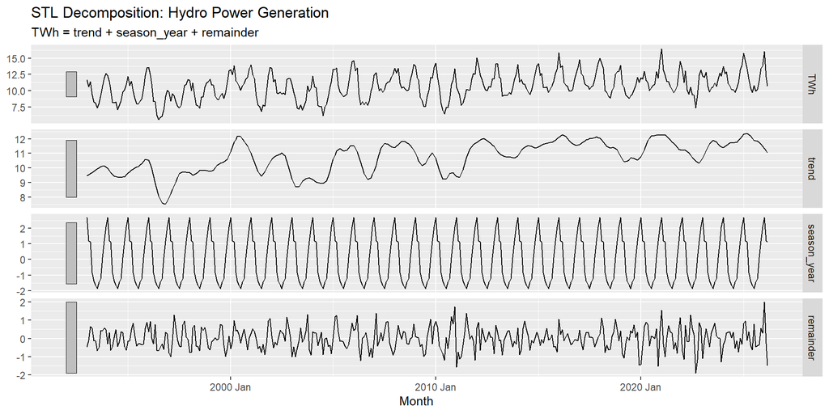

```r
hydro %>%
  model(STL(TWh ~ trend(window = 13) + season(window = "periodic"))) %>%
  components() %>%
  autoplot() +
  labs(title = "STL Decomposition: Hydro Power Generation")
```

## 4.2 STL Decomposition — Log Scale (Robust)

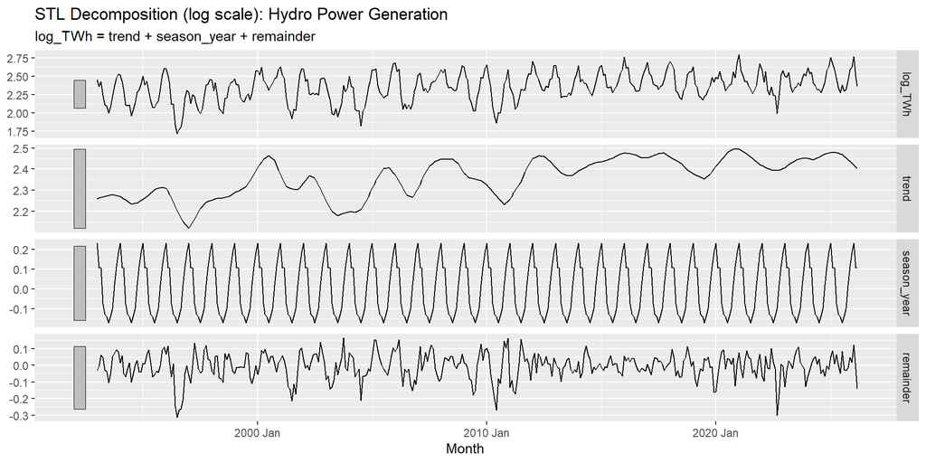

```r
hydro_stl <- hydro %>%
  model(
    STL(log_TWh ~ trend(window = 21) + season(window = "periodic"),
        robust = TRUE)
  )

hydro_stl %>%
  components() %>%
  autoplot() +
  labs(title = "STL Decomposition (log scale): Hydro Power Generation",
       subtitle = "log_TWh = trend + season_year + remainder")
```

To verify the decomposition is adequate, the ACF of the remainder is inspected. Residual autocorrelation would suggest the trend or seasonal windows require adjustment.

```r
hydro_stl %>%
  components() %>%
  pull(remainder) %>%
  Box.test(lag = 24, type = "Ljung-Box")
```

```
##
##  Box-Ljung test
##
## data:  .
## X-squared = 261.72, df = 24, p-value < 2.2e-16
```

**Interpretation:** A Ljung-Box test applied to the STL remainder (lag = 24) yields X² = 261.72 (p < 0.001), decisively rejecting white noise. This indicates that systematic variation remains after trend and seasonal extraction, consistent with the influence of inter-annual reservoir inflow and consequent fill rate variability — motivating the inclusion of reservoir fill rate as an exogenous regressor in the ARIMAX specification.

# 5 Stationarity Tests

## 5.1 Unit Root Tests — Levels

```r
# ADF: H0 = non-stationary (unit root); p < 0.05 → stationary
adf_hydro  <- adf.test(hydro$TWh)
adf_total  <- adf.test(total_elec$TWh)


cat("=== ADF Test (levels) ===\n")
```

```
## === ADF Test (levels) ===
```

```r
cat("Hydro:  Dickey-Fuller =", round(adf_hydro$statistic, 4),
    " | Lag order =", adf_hydro$parameter,
    " | p-value =", round(adf_hydro$p.value, 4), "\n")
```

```
## Hydro:  Dickey-Fuller = -6.4259  | Lag order = 7  | p-value = 0.01
```

```r
cat("Total:  Dickey-Fuller =", round(adf_total$statistic, 4),
    " | Lag order =", adf_total$parameter,
    " | p-value =", round(adf_total$p.value, 4), "\n")
```

```
## Total:  Dickey-Fuller = -6.6245  | Lag order = 7  | p-value = 0.01
```

```r
# KPSS: H0 = stationary; p < 0.05 → non-stationary
kpss_hydro <- hydro       %>% features(TWh, unitroot_kpss)
kpss_total <- total_elec  %>% features(TWh, unitroot_kpss)

cat("\n=== KPSS Test (levels) ===\n")
```

```
##
## === KPSS Test (levels) ===
```

```r
print(kpss_hydro)
```

```
## # A tibble: 1 × 2
##   kpss_stat kpss_pvalue
##       <dbl>       <dbl>
## 1      1.63        0.01
```

```r
print(kpss_total)
```

```
## # A tibble: 1 × 2
##   kpss_stat kpss_pvalue
##       <dbl>       <dbl>
## 1      2.90        0.01
```

```r
# How many differences needed?
ndiff_hydro  <- hydro %>% features(TWh, unitroot_ndiffs)
nsdiff_hydro <- hydro %>% features(TWh, unitroot_nsdiffs)

cat("\n=== Differences Needed ===\n")
```

```
##
## === Differences Needed ===
```

```r
cat("Regular differences:  ", ndiff_hydro$ndiffs,  "\n")
```

```
## Regular differences:   1
```

```r
cat("Seasonal differences: ", nsdiff_hydro$nsdiffs, "\n")
```

```
## Seasonal differences:  1
```

**Interpretation:** The ADF and KPSS tests produce **conflicting results**: ADF rejects non-stationarity (p = 0.01) while KPSS simultaneously rejects stationarity. This is best explained by the strong seasonal pattern — the series is not a random walk (hence ADF), but its persistent annual cycle creates seasonal non-stationarity (hence KPSS). The automatic differencing tests recommend applying **one regular difference and one seasonal difference**.

## 5.2 First Differencing and Re-Testing

```r
hydro <- hydro %>%
  mutate(diff_TWh = difference(TWh))

cat("=== ADF Test (first differences) ===\n")
```

```
## === ADF Test (first differences) ===
```

```r
adf.test(na.omit(hydro$diff_TWh))
```

```
##
##  Augmented Dickey-Fuller Test
##
## data:  na.omit(hydro$diff_TWh)
## Dickey-Fuller = -15.749, Lag order = 7, p-value = 0.01
## alternative hypothesis: stationary
```

```r
cat("\n=== KPSS Test (first differences) ===\n")
```

```
##
## === KPSS Test (first differences) ===
```

```r
kpss.test(na.omit(hydro$diff_TWh))
```

```
##
##  KPSS Test for Level Stationarity
##
## data:  na.omit(hydro$diff_TWh)
## KPSS Level = 0.0064116, Truncation lag parameter = 5, p-value = 0.1
```

**Interpretation:** After first differencing the conflict is resolved, confirming the differenced series is stationary and suitable for ARIMA modelling.

## 5.3 12 month Differencing and Re-Testing

```r
hydro <- hydro %>%
  mutate(sdiff_TWh = difference(TWh, lag = 12))   # seasonal difference at lag 12

cat("=== ADF Test (seasonal difference, D = 1) ===\n")
```

```
## === ADF Test (seasonal difference, D = 1) ===
```

```r
adf.test(na.omit(hydro$sdiff_TWh))
```

```
##
##  Augmented Dickey-Fuller Test
##
## data:  na.omit(hydro$sdiff_TWh)
## Dickey-Fuller = -5.7377, Lag order = 7, p-value = 0.01
## alternative hypothesis: stationary
```

```r
cat("\n=== KPSS Test (seasonal difference, D = 1) ===\n")
```

```
##
## === KPSS Test (seasonal difference, D = 1) ===
```

```r
kpss.test(na.omit(hydro$sdiff_TWh))
```

```
##
##  KPSS Test for Level Stationarity
##
## data:  na.omit(hydro$sdiff_TWh)
## KPSS Level = 0.02162, Truncation lag parameter = 5, p-value = 0.1
```

# 6 Structural Break Analysis

A structural break occurs when the statistical properties of the series change permanently — for example, a shift in mean hydro production due to drought, new capacity, or energy policy.

## 6.1 Identifying the Largest Level Shift

```r
shift_hydro <- hydro %>%
  features(TWh, features = list(shift_level_max))
print(shift_hydro)
```

```
## # A tibble: 1 × 2
##   shift_level_max shift_level_index
##             <dbl>             <dbl>
## 1            2.54                40
```

```r
cat("\nLargest shift at observation:", shift_hydro$shift_level_index, "\n")
```

```
##
## Largest shift at observation: 40
```

```r
hydro %>%
  slice(shift_hydro$shift_level_index) %>%
  kable(digits = 2, align = "c",
        caption = "Month with the Largest Level Shift — Hydro")
```

Month with the Largest Level Shift — Hydro

| Month | TWh | log_TWh | diff_TWh | sdiff_TWh |
| --- | --- | --- | --- | --- |
| 1996 Apr | 8.35 | 2.12 | -2.75 | -1.58 |

```r
shift_total <- total_elec %>%
  features(TWh, features = list(shift_level_max))
print(shift_total)
```

```
## # A tibble: 1 × 2
##   shift_level_max shift_level_index
##             <dbl>             <dbl>
## 1            2.53                40
```

```r
cat("\nLargest shift at observation:", shift_total$shift_level_index, "\n")
```

```
##
## Largest shift at observation: 40
```

```r
total_elec %>%
  slice(shift_total$shift_level_index) %>%
  kable(digits = 2, align = "c",
        caption = "Month with the Largest Level Shift — Total Electricity")
```

Month with the Largest Level Shift — Total Electricity

| Month | TWh |
| --- | --- |
| 1996 Apr | 8.43 |

## 6.2 Chow Test — Is the Shift Statistically Significant?

```r
hydro_df <- hydro %>%
  as_tibble() %>%
  mutate(Lag1 = lag(TWh)) %>%
  filter(!is.na(Lag1))

reg_formula_hydro <- TWh ~ Lag1

chow_hydro <- sctest(reg_formula_hydro,
                     data  = hydro_df,
                     type  = "Chow",
                     point = shift_hydro$shift_level_index)

cat("=== Chow Test: Hydro Power Generation ===\n")
```

```
## === Chow Test: Hydro Power Generation ===
```

```r
print(chow_hydro)
```

```
##
##  Chow test
##
## data:  reg_formula_hydro
## F = 0.80458, p-value = 0.448
```

```r
if (chow_hydro$p.value < 0.05) {
  cat("p < 0.05 → Reject H0 → Structural break IS statistically significant\n")
} else {
  cat("p >= 0.05 → Fail to reject H0 → No significant structural break\n")
}
```

```
## p >= 0.05 → Fail to reject H0 → No significant structural break
```

```r
total_df <- total_elec %>%
  as_tibble() %>%
  mutate(Lag1 = lag(TWh)) %>%
  filter(!is.na(Lag1))

reg_formula_total <- TWh ~ Lag1

chow_total <- sctest(reg_formula_total,
                     data  = total_df,
                     type  = "Chow",
                     point = shift_total$shift_level_index)

cat("=== Chow Test: Total Electricity Generation ===\n")
```

```
## === Chow Test: Total Electricity Generation ===
```

```r
print(chow_total)
```

```
##
##  Chow test
##
## data:  reg_formula_total
## F = 1.1787, p-value = 0.3088
```

```r
if (chow_total$p.value < 0.05) {
  cat("p < 0.05 → Reject H0 → Structural break IS statistically significant\n")
} else {
  cat("p >= 0.05 → Fail to reject H0 → No significant structural break\n")
}
```

```
## p >= 0.05 → Fail to reject H0 → No significant structural break
```

## 6.3 Sup-F (QLR) Test — Data-Driven Break Detection

The QLR test runs a Chow test at every possible point and takes the maximum F-statistic, identifying both whether a break exists and where it most likely occurred.

```r
qlr_hydro  <- Fstats(reg_formula_hydro, data = hydro_df,  from = 0.15)
supf_hydro <- sctest(qlr_hydro, type = "supF")

cat("=== Sup-F Test: Hydro Power Generation ===\n")
```

```
## === Sup-F Test: Hydro Power Generation ===
```

```r
print(supf_hydro)
```

```
##
##  supF test
##
## data:  qlr_hydro
## sup.F = 9.834, p-value = 0.102
```

```r
bp_hydro_auto <- breakpoints(qlr_hydro)
cat("\nOptimal breakpoint at observation:", bp_hydro_auto$breakpoints, "\n")
```

```
##
## Optimal breakpoint at observation: 211
```

```r
hydro_df %>%
  slice(bp_hydro_auto$breakpoints) %>%
  kable(digits = 2, align = "c",
        caption = "Optimal Breakpoint — Hydro Power Generation")
```

Optimal Breakpoint — Hydro Power Generation

| Month | TWh | log_TWh | diff_TWh | sdiff_TWh | Lag1 |
| --- | --- | --- | --- | --- | --- |
| 2010 Aug | 7.43 | 2 | -0.02 | -1.73 | 7.44 |

```r
qlr_total  <- Fstats(reg_formula_total, data = total_df,  from = 0.15)
supf_total <- sctest(qlr_total, type = "supF")

cat("=== Sup-F Test: Total Electricity Generation ===\n")
```

```
## === Sup-F Test: Total Electricity Generation ===
```

```r
print(supf_total)
```

```
##
##  supF test
##
## data:  qlr_total
## sup.F = 12.976, p-value = 0.02772
```

```r
bp_total_auto <- breakpoints(qlr_total)
cat("\nOptimal breakpoint at observation:", bp_total_auto$breakpoints, "\n")
```

```
##
## Optimal breakpoint at observation: 220
```

```r
total_df %>%
  slice(bp_total_auto$breakpoints) %>%
  kable(digits = 2, align = "c",
        caption = "Optimal Breakpoint — Total Electricity Generation")
```

Optimal Breakpoint — Total Electricity Generation

| Month | TWh | Lag1 |
| --- | --- | --- |
| 2011 May | 8.64 | 8.43 |

## 6.4 Visualising the F-Statistics

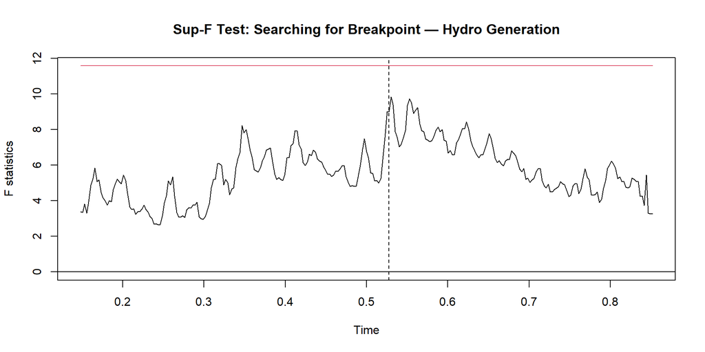

```r
plot(qlr_hydro,
     main = "Sup-F Test: Searching for Breakpoint — Hydro Generation")
lines(breakpoints(qlr_hydro))
```

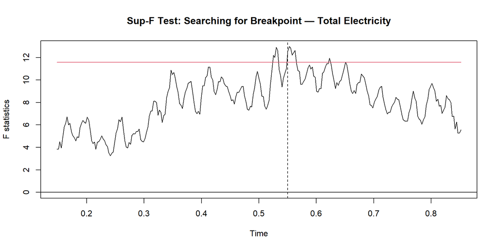

```r
plot(qlr_total,
     main = "Sup-F Test: Searching for Breakpoint — Total Electricity")
lines(breakpoints(qlr_total))
```

## 6.5 Visualising the Break in Context

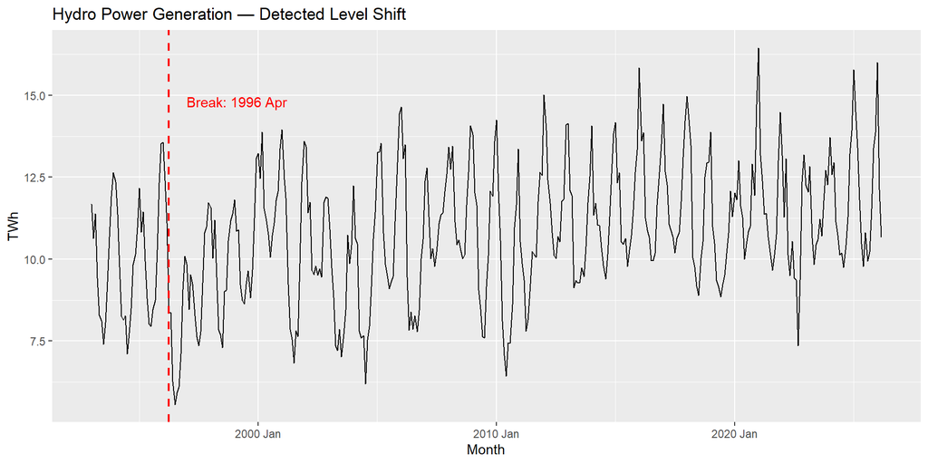

```r
hydro %>%
  autoplot(TWh) +
  geom_vline(xintercept = yearmonth("1996 Apr"),
             color = "red", linetype = "dashed", linewidth = 0.8) +
  annotate("text", x = yearmonth("1997 Jan"), y = max(hydro$TWh, na.rm = TRUE) * 0.9,
           label = "Break: 1996 Apr", color = "red", hjust = 0) +
  labs(title = "Hydro Power Generation — Detected Level Shift",
       y = "TWh", x = "Month")
```

# 7 Model Identification — ACF & PACF

## 7.1 Raw Series

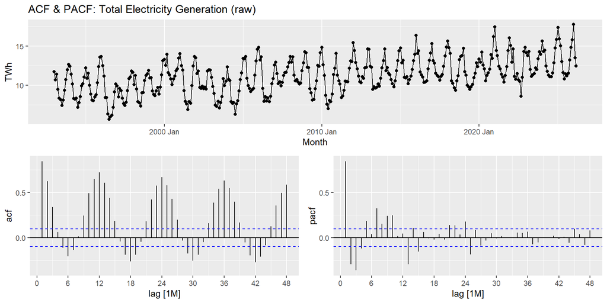

```r
total_elec %>%
  gg_tsdisplay(TWh, plot_type = "partial", lag_max = 48) +
  labs(title = "ACF & PACF: Total Electricity Generation (raw)")
```

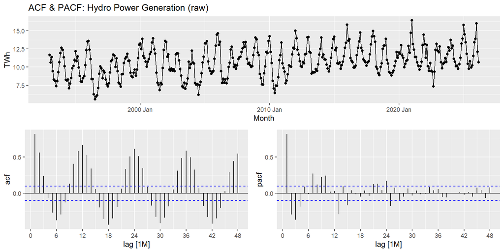

```r
hydro %>%
  gg_tsdisplay(TWh, plot_type = "partial", lag_max = 48) +
  labs(title = "ACF & PACF: Hydro Power Generation (raw)")
```

**Reading the raw ACF/PACF:** The ACF of the raw series decays very slowly and shows large spikes at lags 12, 24, 36, and 48, with large negative spikes at lags 6, 18, and 30 (the opposite season). This slow, persistent decay is the hallmark of **seasonal non-stationarity** and tells us differencing is necessary before we can identify the model order. The PACF shows large direct effects at lag 1 and some residual seasonal structure at lag 12, but the remainder of the pattern is difficult to interpret until stationarity is achieved.